# Project WEEK4 Presentation: Bisector Method

14 de junio de 2018

## Introduction

The Euler method also called bisector method is presented with an R code. These powerful method is commonly used to:

- Fill missing values,
- Find out the minimum or maximum of a function, and
- Integrate differential equations.

The first case is presented here.

Bisector method find an approximation to the known value of a function from two known values of that function.

If x1 and x2 are the variables of function f(x) for which we know the values of f(x1) and f(x2) and normally we do not know the function f(x). The bisector method estimate the value of f(x) for x in the middle of x1 and x2 as a half of the sum of f(x1) and f(x2).

## Data

-Input

```
- Simple case: two points x1 =2, x2= 8
- Function known values: f(x1)= 4, f(x2)= 64
  This vlaues are calculated internally for the example, with a function  but cuold be any function or just put the       values f(x) for x1 and x2
```

- Output
  - A matrix in which the values of the second row is the value of x that bisects the range (x1,x2) and the value estimated for f
  - Rows 1 and 3 are the x1 and x2 in column 1 and f(x1) ,f(x2) in second column.

  To illustrate a graph is shown

## R Code and Output

```r
Vect<-matrix(c(2,3,8,0,0,0),3,2)   #Initialice the matrix and defining the x1 x2.
Vect[,2]<- (Vect[,1])^2 #Defining the values of f(x1) andf(x2)
Vect[2,]<- (Vect[1,]+Vect[3,])/2 # applying  bisector method
#to define values of row 2
Vect
```

```
##      [,1] [,2]
## [1,]    2    4
## [2,]    5   34
## [3,]    8   64
```

## Plot

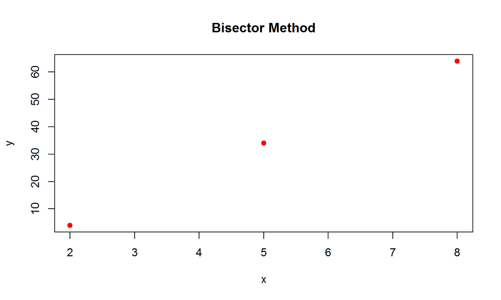